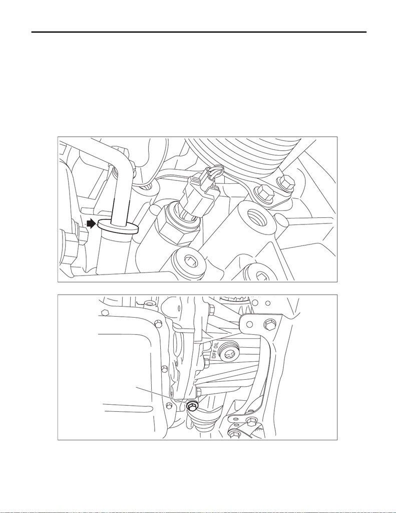

Differential Gear Oil

CONTINUOUSLY VARIABLE TRANSMISSION

3. Differential Gear Oil

A: INSPECTION

Check that there is no leakage of differential gear oil from the converter case.

B: ADJUSTMENT

NOTE:

overflow pipe. This is not included in the specified amount. When removing the overflow drain plug, make

sure the gear oil flows out of the overflow drain plug hole by filling with gear oil.

1) Lift up the vehicle.

2) Remove the air breather cap.

3) Remove the overflow drain plug.

(A) Overflow drain plug

AT-07830

(A)

AT-07828

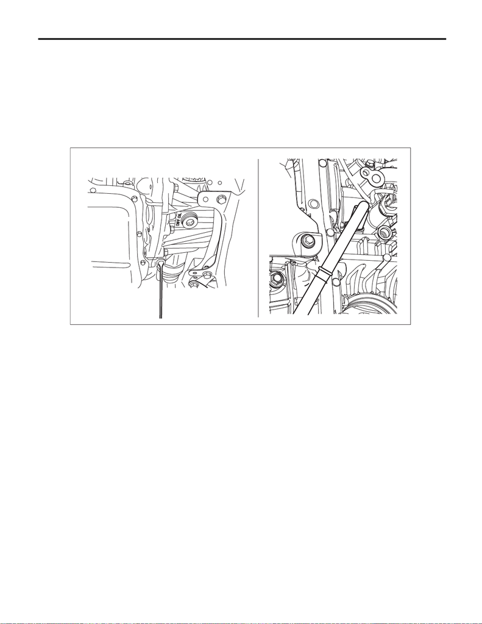

Differential Gear Oil

CONTINUOUSLY VARIABLE TRANSMISSION

4) Fill in the differential gear oil through the charge pipe up to where the oil flows out of the overflow drain

plug.

Recommended gear oil:

<Ref. to CVT(TR690)-4, FRONT DIFFERENTIAL GEAR OIL, SPECIFICATION, General Description.>

5) When the flow of the differential gear oil turns into a narrow stream, install the overflow drain plug.

NOTE:

Use a new gasket.

Tightening torque:

35 N·m (3.6 kgf-m, 25.8 ft-lb)

6) Install the air breather cap.

C: REPLACEMENT

CAUTION:

• Immediately after the vehicle has been running or after idling for a long time, the differential gear

oil will be hot. Be careful not to burn yourself.

• Be careful not to spill differential gear oil on the exhaust pipe to prevent it from emitting smoke or

causing a fire. If gear oil adheres, wipe it off completely.

1) Lift up the vehicle.

2) Remove the differential gear oil drain plug using TORX

bit T70. Drain differential gear oil.

AT-07832

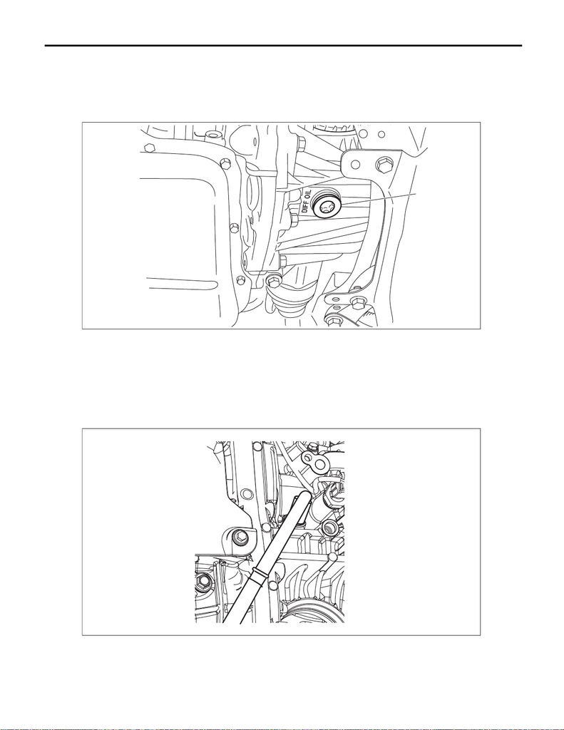

Differential Gear Oil

CONTINUOUSLY VARIABLE TRANSMISSION

3) Install the differential gear oil drain plug using TORX

®

bit T70.

NOTE:

Use a new gasket.

Tightening torque:

70 N·m (7.1 kgf-m, 51.6 ft-lb)

4) Pour gear oil from the charge pipe.

Recommended gear oil:

<Ref. to CVT(TR690)-4, FRONT DIFFERENTIAL GEAR OIL, SPECIFICATION, General Description.>

Gear oil capacity:

<Ref. to CVT(TR690)-4, FRONT DIFFERENTIAL GEAR OIL, SPECIFICATION, General Description.>

5) Adjust the level of differential gear oil. <Ref. to CVT(TR690)-41, ADJUSTMENT, Differential Gear Oil.>

(A) Differential gear oil drain plug

(A)

AT-07751

AT-07833